# **Ensemble Techniques: EasyVisa Project**

### **Important Features of the Final Model**

- Here, one can see that the most important feature in the Gradient boost classifier model is the education of employee with at least a high school diploma.
- This is followed by job experiences being none, education with at least a Bachelor's, and unit of wage in terms of hour.
- These features are very important when determining whether or not a foreign employee would be certified to work in the US.

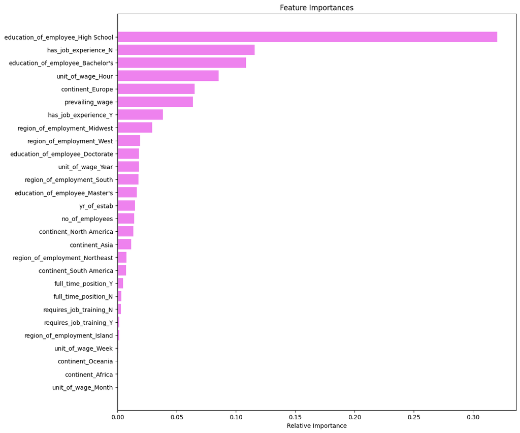

```python
feature_names = X_train.columns
importances = gb_classifier.feature_importances_
indices = np.argsort(importances)

plt.figure(figsize=(12, 12))
plt.title("Feature Importances")
plt.barh(range(len(indices)), importances[indices], color="violet", align="center")
plt.yticks(range(len(indices)), [feature_names[i] for i in indices])
plt.xlabel("Relative Importance")
plt.show()
```

## **Business Insights and Recommendations**

- Based on the analysis, the Office of Foreign Labor Certification (OFLC) should focus on foreign employees who have obtained at least a high school diploma or preferably a Bachelor's degree, and have some prior job experience.
- While the model shows that the unit of wage in terms of hourly rates is important, I do not recommend the OFLC to deny foreign workers who report as such as this depends on the companies they work at and comes after the three aformentioned features anyway.
- The model also shows that employees who come from Europe are more likely to get certified compared to those from other continents. I advise the OFLC to not be biased towards Europe and to maintain a fair, non-discriminatory stance regarding the origin and racial background of the applicants.
- Overall, the top three factors mentioned in the first point should be the only criteria that the OFLC must consider because we want to ensure that we can attract skilled, educated foreign workers from all around the world to work in the US and boosting the economy in the process.